# Tugas Pertemuan 4 | Simulasi Proses MA(2), AR(2), dan ARMA(2,2)

## Pendahuluan

Pada latihan ini dibangkitkan tiga proses deret waktu, yaitu **MA(2)**, **AR(2)**, dan **ARMA(2,2)**, masing-masing sebanyak **300 data**, dengan dua cara: **manual** (menggunakan *loop*) dan fungsi **`arima.sim()`**. Untuk setiap proses akan dilakukan:

1. Pembuatan plot time series, ACF, PACF, dan EACF, serta identifikasi kestasioneran data
2. Pembuatan scatterplot antara $Y_t$ dengan $Y_{t-1}$, $Y_t$ dengan $Y_{t-2}$, dan $Y_t$ dengan $Y_{t-3}$
3. Perhitungan autokorelasi lag 1, 2, dan 3 dari data bangkitan (empiris) maupun secara teoritis

Ketiga proses dibangkitkan dari *white noise* yang sama agar hasilnya dapat dibandingkan secara konsisten.

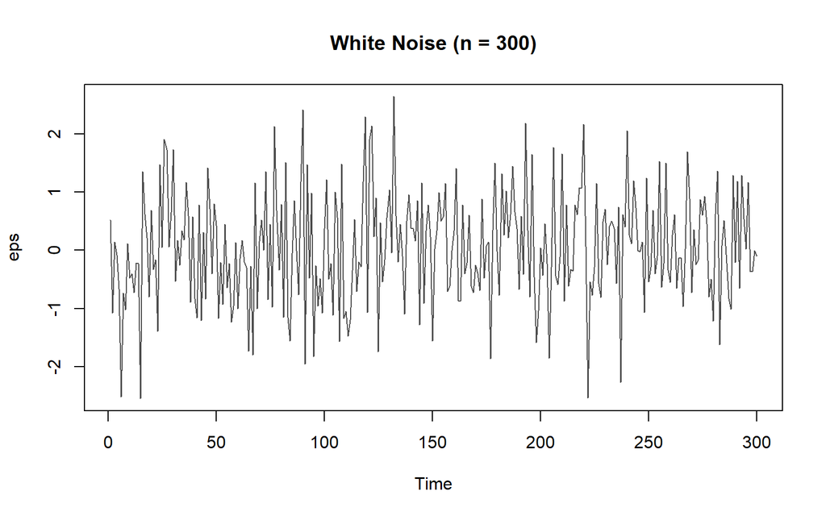

```r
set.seed(2026)
n <- 300
eps <- rnorm(n)
ts.plot(eps, main = "White Noise (n = 300)", col = "grey30")
```

Package `TSA` dipakai untuk membuat plot EACF.

```r
library(TSA)
```

# 1. Proses MA(2)

Proses MA(2) dirumuskan sebagai:

$$Y_t = e_t + \theta_1 e_{t-1} + \theta_2 e_{t-2}$$

dengan $\theta_1 = 0.4$ dan $\theta_2 = 0.6$.

## 1.1 Pembangkitan Data MA(2)

### Cara Manual

Nilai $Y_t$ pada MA(2) membutuhkan dua *lag* dari *white noise* ($e_{t-1}$ dan $e_{t-2}$). Karena $e_0$ dan $e_{-1}$ tidak tersedia, dua nilai pertama dibangkitkan secara khusus, lalu sisanya dibangkitkan dengan *loop*.

```r
th1_ma <- 0.4
th2_ma <- 0.6

ma2 <- numeric(n)
ma2[1] <- eps[1]
ma2[2] <- eps[2] + th1_ma * eps[1]
for (i in 3:n) {
  ma2[i] <- eps[i] + th1_ma * eps[i - 1] + th2_ma * eps[i - 2]
}
head(ma2, 10)
```

```
##  [1]  0.52058907 -0.87145513  0.01971525 -0.67686800 -0.61699626 -2.83359415
##  [7] -2.14156618 -2.82383440 -0.73558254 -1.04044256
```

### Menggunakan `arima.sim()`

```r
set.seed(2027)
ma2.sim <- arima.sim(list(order = c(0, 0, 2), ma = c(th1_ma, th2_ma)), n = n)
head(ma2.sim, 10)
```

```
## Time Series:
## Start = 1
## End = 10
## Frequency = 1
##  [1] -1.3864170  0.1307752  1.8298415  1.9547260  0.3279303 -0.6110644
##  [7] -2.4867637 -1.7610988 -2.6580293 -1.5358209
```

## 1.2 Karakteristik MA(2) dan Identifikasi Kestasioneran

### Plot Time Series

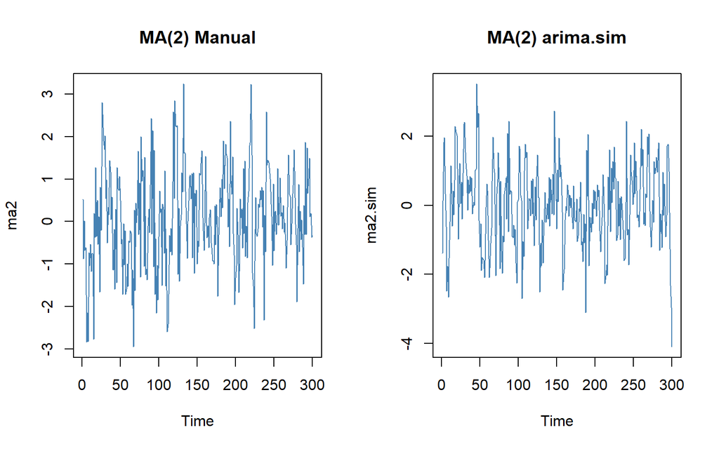

```r
par(mfrow = c(1, 2))
ts.plot(ma2, main = "MA(2) Manual", col = "steelblue")
ts.plot(ma2.sim, main = "MA(2) arima.sim", col = "steelblue")
```

```r
par(mfrow = c(1, 1))
```

Kedua plot time series bergerak di sekitar rataan yang konstan (mendekati 0), dengan ragam yang relatif stabil dan tanpa pola tren maupun musiman. Jadi, data MA(2) hasil bangkitan **stasioner dalam rataan dan ragam**. Hal ini sesuai teori bahwa **proses MA (berorde hingga) selalu stasioner**, sebab $Y_t$ hanya kombinasi linear terbatas dari *white noise*.

### Plot ACF

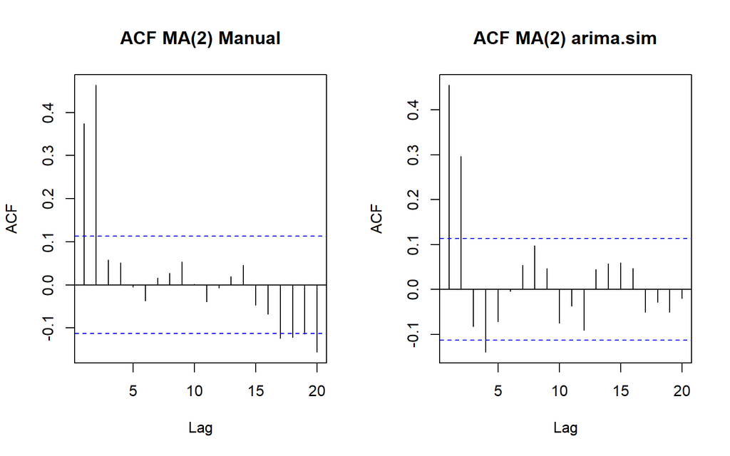

```r
par(mfrow = c(1, 2))
acf(ma2, lag.max = 20, main = "ACF MA(2) Manual")
acf(ma2.sim, lag.max = 20, main = "ACF MA(2) arima.sim")
```

```r
par(mfrow = c(1, 1))
```

Plot ACF nyata (signifikan) pada lag 1 dan lag 2, kemudian *cuts off* (terputus) setelah lag ke-2. Ini sesuai teori MA(2), yaitu autokorelasi teoritis bernilai nol untuk lag $k>2$.

### Plot PACF

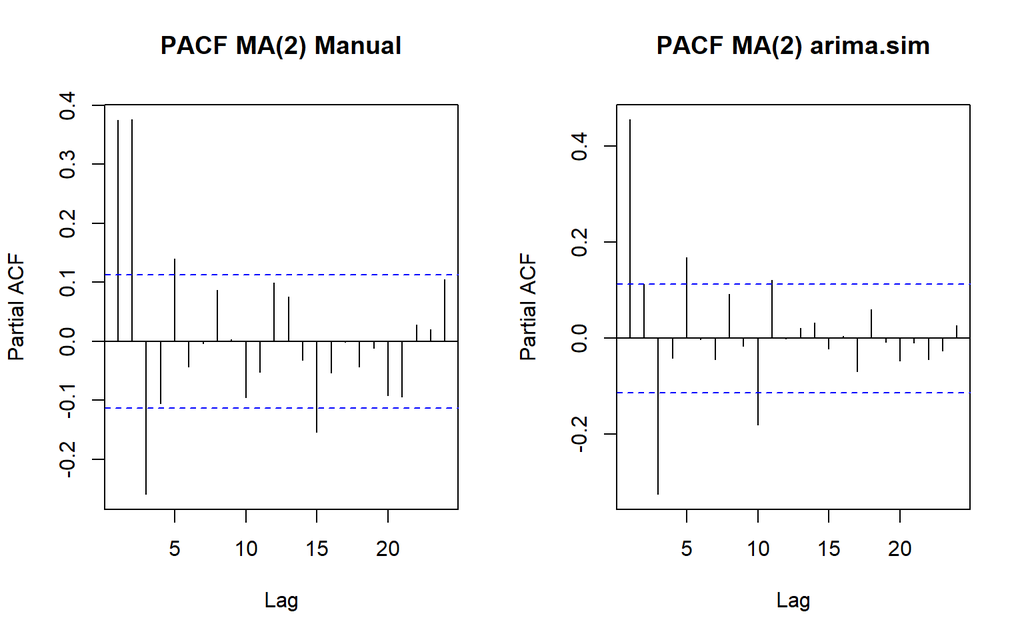

```r
par(mfrow = c(1, 2))
pacf(ma2, main = "PACF MA(2) Manual")
pacf(ma2.sim, main = "PACF MA(2) arima.sim")
```

```r
par(mfrow = c(1, 1))
```

Plot PACF cenderung *tails off* (meluruh perlahan) menuju nol dan tidak terputus tegas pada satu lag tertentu. Pola ACF *cuts off* dan PACF *tails off* merupakan ciri khas proses MA.

### Plot EACF

```r
TSA::eacf(ma2)
```

```
## AR/MA
##   0 1 2 3 4 5 6 7 8 9 10 11 12 13
## 0 x x o o o o o o o o o  o  o  o
## 1 x x x o o o o o o o o  o  o  o
## 2 x x o x o o o o o o o  o  o  o
## 3 x x x x o o o o o o o  o  o  o
## 4 x x o x o x o o o o o  o  o  o
## 5 x x o x x o x o o o o  o  o  o
## 6 x o x x x o x o o o o  o  o  o
## 7 o x x o o o x o o o o  o  o  o
```

```r
TSA::eacf(ma2.sim)
```

```
## AR/MA
##   0 1 2 3 4 5 6 7 8 9 10 11 12 13
## 0 x x o x o o o o o o o  o  o  o
## 1 x x x x o o o o o x o  o  o  o
## 2 x x x o o o o o o o o  o  o  o
## 3 x x x o o o o o o o o  o  o  o
## 4 x x x x o o o o o o o  o  o  o
## 5 o x x x o o o o o o o  o  o  o
## 6 o o x x o o o o o o o  o  o  o
## 7 x x o o o o o o o o o  o  o  o
```

Segitiga nol pada plot EACF berada pada baris ordo AR = 0 dan kolom ordo MA = 2, sehingga EACF mengidentifikasi proses ini sebagai **MA(2)**, sesuai model yang dibangkitkan.

**Kesimpulan:** data MA(2) hasil bangkitan bersifat **stasioner**, baik secara visual (plot time series) maupun secara teori (MA berorde hingga selalu stasioner), dan ordo modelnya teridentifikasi benar melalui pola ACF/PACF/EACF.

## 1.3 Scatterplot Antar Lag

Analisis berikut memakai data hasil pembangkitan manual (`ma2`).

#### Korelasi antara $Y_t$ dengan $Y_{t-1}$

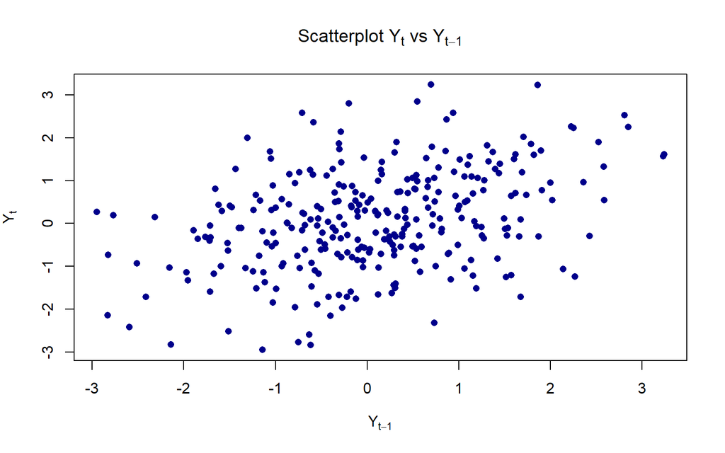

```r
# Yt
yt_ma2 <- ma2[-1]
# Yt-1
yt1_ma2 <- ma2[-n]

plot(y = yt_ma2, x = yt1_ma2, pch = 16, col = "darkblue",
     main = expression(paste("Scatterplot ", Y[t], " vs ", Y[t-1])),
     xlab = expression(Y[t-1]), ylab = expression(Y[t]))
```

```r
cor(yt_ma2, yt1_ma2)
```

```
## [1] 0.3747571
```

Tampak hubungan positif antara $Y_t$ dan $Y_{t-1}$, sesuai teori (koefisien $\theta_1$ dan $\theta_2$ sama-sama positif).

#### Korelasi antara $Y_t$ dengan $Y_{t-2}$

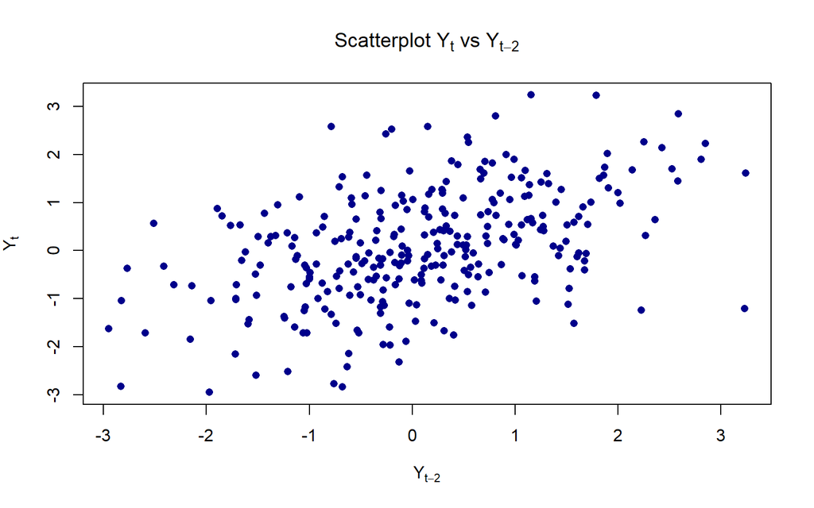

```r
# Yt
yt_ma2_2 <- ma2[-c(1, 2)]
# Yt-2
yt2_ma2 <- ma2[-c(n - 1, n)]

plot(y = yt_ma2_2, x = yt2_ma2, pch = 16, col = "darkblue",
     main = expression(paste("Scatterplot ", Y[t], " vs ", Y[t-2])),
     xlab = expression(Y[t-2]), ylab = expression(Y[t]))
```

```r
cor(yt_ma2_2, yt2_ma2)
```

```
## [1] 0.4638757
```

#### Korelasi antara $Y_t$ dengan $Y_{t-3}$

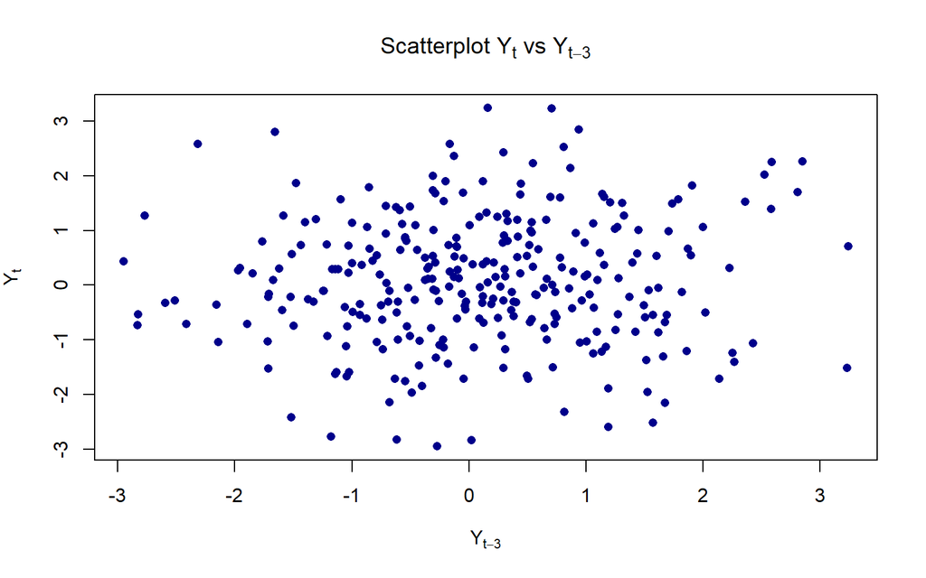

```r
# Yt
yt_ma2_3 <- ma2[-c(1, 2, 3)]
# Yt-3
yt3_ma2 <- ma2[-c(n - 2, n - 1, n)]

plot(y = yt_ma2_3, x = yt3_ma2, pch = 16, col = "darkblue",
     main = expression(paste("Scatterplot ", Y[t], " vs ", Y[t-3])),
     xlab = expression(Y[t-3]), ylab = expression(Y[t]))
```

```r
cor(yt_ma2_3, yt3_ma2)
```

```
## [1] 0.05774366
```

Titik-titik menyebar tanpa pola yang jelas, artinya hampir tidak ada hubungan linear antara $Y_t$ dan $Y_{t-3}$, sesuai teori bahwa $\rho_3 = 0$ pada MA(2).

## 1.4 Autokorelasi: Data Bangkitan vs Teoritis

Autokorelasi teoritis MA(2) pada lag $k$ (dengan $\theta_0=1$) adalah:

$$\rho_k =
\frac{\sum_{i=0}^{2-k}\theta_i\theta_{i+k}}{1+\theta_1^2+\theta_2^2},
\quad k = 1, 2 \qquad ; \qquad \rho_k = 0 \text{ untuk } k>2$$

sehingga:

$$\rho_1=\frac{\theta_1(1+\theta_2)}{1+\theta_1^2+\theta_2^2}=\frac{0.4(1+0.6)}{1+0.4^2+0.6^2}=\frac{0.64}{1.52}=0.4211$$

$$\rho_2=\frac{\theta_2}{1+\theta_1^2+\theta_2^2}=\frac{0.6}{1.52}=0.3947$$

$$\rho_3 = 0$$

Nilai tersebut juga dapat diverifikasi di R dengan `ARMAacf()`:

```r
ARMAacf(ma = c(th1_ma, th2_ma), lag.max = 3, pacf = FALSE)
```

```
##         0         1         2         3
## 1.0000000 0.4210526 0.3947368 0.0000000
```

**Perbandingan hasil:**

| Lag | Autokorelasi Data Bangkitan | Autokorelasi Teoritis |
| --- | --- | --- |
| 1 | 0.3748 | 0.4211 |
| 2 | 0.4639 | 0.3947 |
| 3 | 0.0577 | 0 |

Autokorelasi dari data bangkitan **mendekati** nilai teoritisnya, sehingga data hasil pembangkitan sudah cukup mewakili model MA(2) yang diinginkan.

# 2. Proses AR(2)

Proses AR(2) dirumuskan sebagai:

$$Y_t = \phi_1 Y_{t-1} + \phi_2 Y_{t-2} + e_t$$

dengan $\phi_1 = 0.5$ dan $\phi_2 = 0.2$.

## 2.1 Pembangkitan Data AR(2)

### Cara Manual

Seperti pada MA(2), dua nilai pertama dibangkitkan secara khusus (karena $Y_0$ tidak tersedia untuk nilai kedua), lalu sisanya dibangkitkan dengan *loop*.

```r
ph1_ar <- 0.5
ph2_ar <- 0.2

ar2 <- numeric(n)
ar2[1] <- eps[1]
ar2[2] <- ph1_ar * ar2[1] + eps[2]
for (i in 3:n) {
  ar2[i] <- ph1_ar * ar2[i - 1] + ph2_ar * ar2[i - 2] + eps[i]
}
head(ar2, 10)
```

```
##  [1]  0.5205891 -0.8193962 -0.1663422 -0.3317991 -0.8658076 -3.0153527
##  [7] -2.4159847 -2.8311851 -1.7852350 -1.9326455
```

### Menggunakan `arima.sim()`

```r
set.seed(2028)
ar2.sim <- arima.sim(list(order = c(2, 0, 0), ar = c(ph1_ar, ph2_ar)), n = n)
head(ar2.sim, 10)
```

```
## Time Series:
## Start = 1
## End = 10
## Frequency = 1
##  [1]  1.20841222  0.92503868  0.74578263  0.72808409 -0.93783588 -0.04142002
##  [7]  0.23631363 -1.21695186  0.19152357 -1.32923267
```

## 2.2 Karakteristik AR(2) dan Identifikasi Kestasioneran

Sebelum melihat plot, kestasioneran AR(2) dapat dicek secara teoritis dengan syarat berikut:

$$\phi_1+\phi_2<1, \qquad \phi_2-\phi_1<1, \qquad -1<\phi_2<1$$

Untuk $\phi_1=0.5$ dan $\phi_2=0.2$: $\phi_1+\phi_2=0.7<1$ ✓, $\phi_2-\phi_1=-0.3<1$ ✓, $-1<0.2<1$ ✓. Ketiga syarat terpenuhi, sehingga **proses AR(2) ini stasioner**.

### Plot Time Series

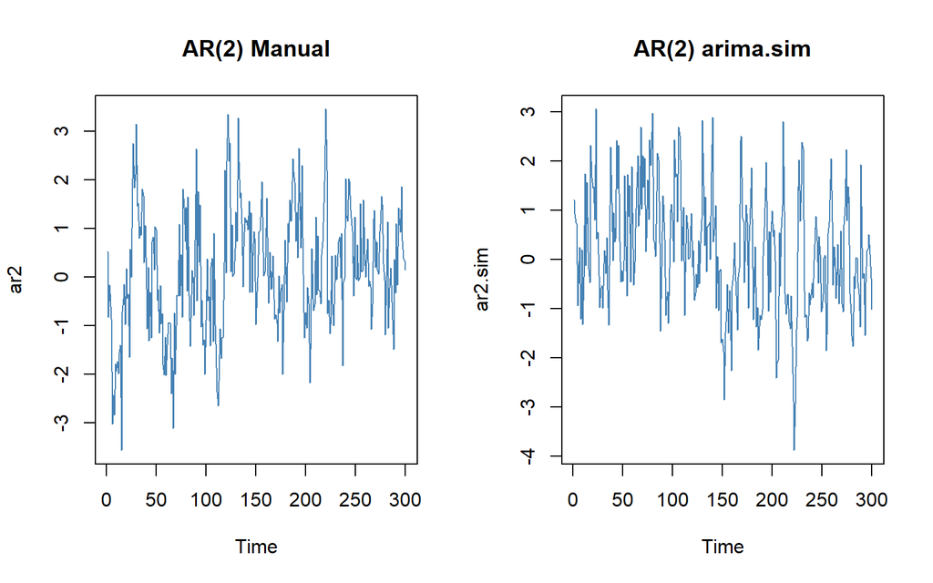

```r
par(mfrow = c(1, 2))
ts.plot(ar2, main = "AR(2) Manual", col = "steelblue")
ts.plot(ar2.sim, main = "AR(2) arima.sim", col = "steelblue")
```

```r
par(mfrow = c(1, 1))
```

Kedua plot bergerak di sekitar rataan konstan tanpa tren maupun perubahan ragam yang mencolok, sehingga data **stasioner dalam rataan**, sejalan dengan hasil pengecekan syarat kestasioneran di atas.

### Plot ACF

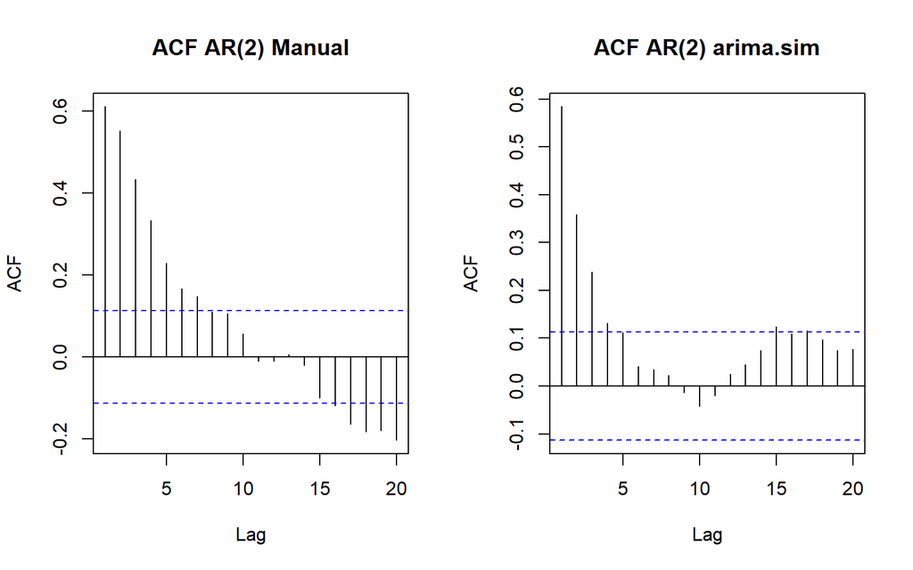

```r
par(mfrow = c(1, 2))
acf(ar2, lag.max = 20, main = "ACF AR(2) Manual")
acf(ar2.sim, lag.max = 20, main = "ACF AR(2) arima.sim")
```

```r
par(mfrow = c(1, 1))
```

Plot ACF cenderung *tails off* (meluruh perlahan menuju nol) dan tidak terputus tegas pada lag tertentu, sesuai teori proses AR.

### Plot PACF

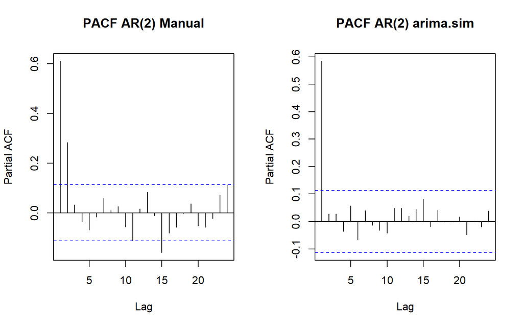

```r
par(mfrow = c(1, 2))
pacf(ar2, main = "PACF AR(2) Manual")
pacf(ar2.sim, main = "PACF AR(2) arima.sim")
```

```r
par(mfrow = c(1, 1))
```

### Plot EACF

```r
TSA::eacf(ar2)
```

```
## AR/MA
##   0 1 2 3 4 5 6 7 8 9 10 11 12 13
## 0 x x x x x x x o o o o  o  o  o
## 1 x o o o o o o o o o o  o  o  o
## 2 o x o o o o o o o o o  o  o  o
## 3 x o x o o o o o o o o  o  o  o
## 4 x x o o o o o o o o o  o  o  o
## 5 x x o o o o o o o o o  o  o  o
## 6 x x x x o o o o o o o  o  o  o
## 7 x x x x o o o o o o o  o  o  o
```

```r
TSA::eacf(ar2.sim)
```

```
## AR/MA
##   0 1 2 3 4 5 6 7 8 9 10 11 12 13
## 0 x x x x o o o o o o o  o  o  o
## 1 o o o o o o o o o o o  o  o  o
## 2 x o o o o o o o o o o  o  o  o
## 3 x o o o o o o o o o o  o  o  o
## 4 x x o o o o o o o o o  o  o  o
## 5 x x x x o o o o o o o  o  o  o
## 6 x x x o o o o o o o o  o  o  o
## 7 x x o o o o o o o o o  o  o  o
```

## 2.3 Scatterplot Antar Lag

Analisis berikut memakai data hasil pembangkitan manual (`ar2`).

#### Korelasi antara $Y_t$ dengan $Y_{t-1}$

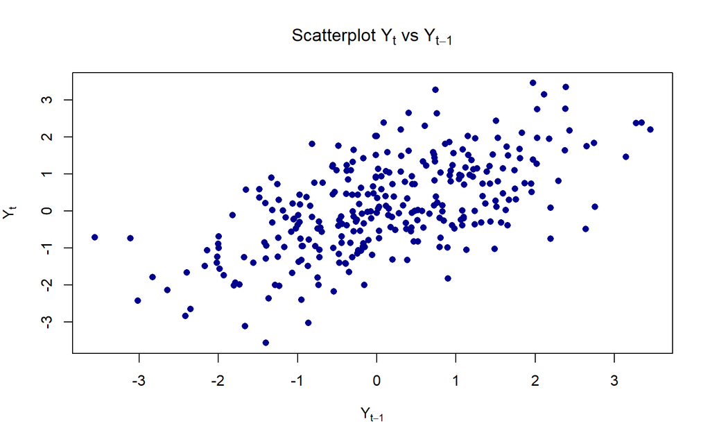

```r
# Yt
yt_ar2 <- ar2[-1]
# Yt-1
yt1_ar2 <- ar2[-n]

plot(y = yt_ar2, x = yt1_ar2, pch = 16, col = "darkblue",
     main = expression(paste("Scatterplot ", Y[t], " vs ", Y[t-1])),
     xlab = expression(Y[t-1]), ylab = expression(Y[t]))
```

```r
cor(yt_ar2, yt1_ar2)
```

```
## [1] 0.6107934
```

Tampak hubungan positif yang kuat antara $Y_t$ dan $Y_{t-1}$, sesuai sifat AR(2) yang memiliki ketergantungan (autokorelasi) tinggi pada lag-lag awal.

#### Korelasi antara $Y_t$ dengan $Y_{t-2}$

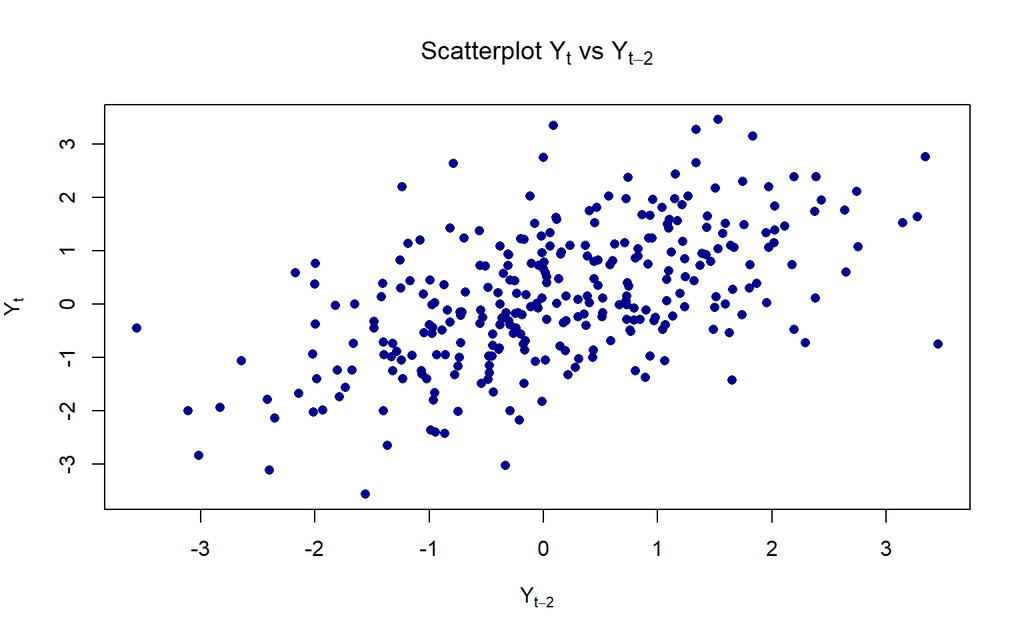

```r
# Yt
yt_ar2_2 <- ar2[-c(1, 2)]
# Yt-2
yt2_ar2 <- ar2[-c(n - 1, n)]

plot(y = yt_ar2_2, x = yt2_ar2, pch = 16, col = "darkblue",
     main = expression(paste("Scatterplot ", Y[t], " vs ", Y[t-2])),
     xlab = expression(Y[t-2]), ylab = expression(Y[t]))
```

```r
cor(yt_ar2_2, yt2_ar2)
```

```
## [1] 0.5518364
```

Hubungan positif masih terlihat jelas, sesuai teori bahwa pada AR(2) autokorelasi meluruh bertahap dan tidak langsung nol pada lag 2.

#### Korelasi antara $Y_t$ dengan $Y_{t-3}$

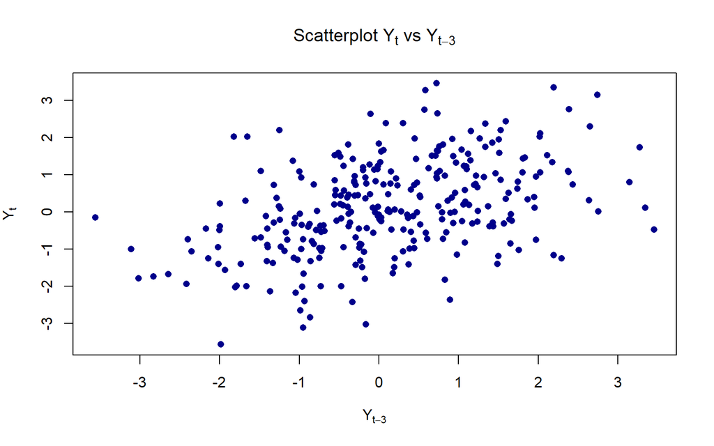

```r
# Yt
yt_ar2_3 <- ar2[-c(1, 2, 3)]
# Yt-3
yt3_ar2 <- ar2[-c(n - 2, n - 1, n)]

plot(y = yt_ar2_3, x = yt3_ar2, pch = 16, col = "darkblue",
     main = expression(paste("Scatterplot ", Y[t], " vs ", Y[t-3])),
     xlab = expression(Y[t-3]), ylab = expression(Y[t]))
```

```r
cor(yt_ar2_3, yt3_ar2)
```

```
## [1] 0.4339809
```

Hubungan positif masih tampak walau melemah dibanding lag 1 dan 2, sesuai sifat ACF AR(2) yang *tails off* secara perlahan.

## 2.4 Autokorelasi: Data Bangkitan vs Teoritis

Autokorelasi teoritis AR(2) diperoleh dari persamaan Yule-Walker:

$$\rho_k = \phi_1\rho_{k-1}+\phi_2\rho_{k-2}, \quad \rho_0=1$$

$$\rho_1=\frac{\phi_1}{1-\phi_2}=\frac{0.5}{1-0.2}=\frac{0.5}{0.8}=0.625$$

$$\rho_2=\phi_1\rho_1+\phi_2\rho_0=0.5(0.625)+0.2(1)=0.5125$$

$$\rho_3=\phi_1\rho_2+\phi_2\rho_1=0.5(0.5125)+0.2(0.625)=0.3813$$

Verifikasi dengan `ARMAacf()`:

```r
ARMAacf(ar = c(ph1_ar, ph2_ar), lag.max = 3, pacf = FALSE)
```

```
##       0       1       2       3
## 1.00000 0.62500 0.51250 0.38125
```

**Perbandingan hasil:**

| Lag | Autokorelasi Data Bangkitan | Autokorelasi Teoritis |
| --- | --- | --- |
| 1 | 0.6108 | 0.6250 |
| 2 | 0.5518 | 0.5125 |
| 3 | 0.434 | 0.3813 |

Autokorelasi dari data bangkitan **mendekati** nilai teoritisnya, menunjukkan pembangkitan AR(2) sudah sesuai dengan model yang ditetapkan.

# 3. Proses ARMA(2,2)

Proses ARMA(2,2) dirumuskan sebagai:

$$Y_t = \phi_1 Y_{t-1} + \phi_2 Y_{t-2} + e_t + \theta_1 e_{t-1} +
\theta_2 e_{t-2}$$

dengan $\phi_1 = 0.5$, $\phi_2 = 0.2$, $\theta_1 = 0.4$, dan $\theta_2 = 0.6$ (koefisien yang sama dengan bagian AR(2) dan MA(2) sebelumnya).

## 3.1 Pembangkitan Data ARMA(2,2)

### Cara Manual

```r
phi1 <- 0.5; phi2 <- 0.2
theta1 <- 0.4; theta2 <- 0.6

arma22 <- numeric(n)
arma22[1] <- eps[1]
arma22[2] <- phi1 * arma22[1] + eps[2] + theta1 * eps[1]
for (i in 3:n) {
  arma22[i] <- phi1 * arma22[i - 1] + phi2 * arma22[i - 2] +
               eps[i] + theta1 * eps[i - 1] + theta2 * eps[i - 2]
}
head(arma22, 10)
```

```
##  [1]  0.5205891 -0.6111606 -0.1817472 -0.8899737 -1.0983326 -3.5607552
##  [7] -4.1416103 -5.6067906 -4.3672999 -4.3454506
```

### Menggunakan `arima.sim()`

```r
set.seed(2029)
arma22.sim <- arima.sim(list(order = c(2, 0, 2), ar = c(phi1, phi2), ma = c(theta1, theta2)), n = n)
head(arma22.sim, 10)
```

```
## Time Series:
## Start = 1
## End = 10
## Frequency = 1
##  [1]  2.1035296  0.8946133 -0.1793680 -1.3104007 -3.4871613 -2.5331927
##  [7] -2.4667873 -4.3352761 -3.1799801 -4.6278861
```

## 3.2 Karakteristik ARMA(2,2) dan Identifikasi Kestasioneran

**Kestasioneran (bagian AR)** dicek dengan syarat yang sama seperti AR(2): $\phi_1+\phi_2=0.7<1$, $\phi_2-\phi_1=-0.3<1$, $-1<\phi_2<1$ → **terpenuhi, stasioner**.

**Invertibilitas (bagian MA)** dicek dari akar polinomial $1+\theta_1 z+\theta_2 z^2=0$. Untuk $\theta_1=0.4,\ \theta_2=0.6$, diskriminan $=0.4^2-4(0.6)(1)=-2.24<0$ (akar kompleks) dengan modulus $\sqrt{1/0.6}=1.291>1$, sehingga **memenuhi syarat invertibel**.

### Plot Time Series

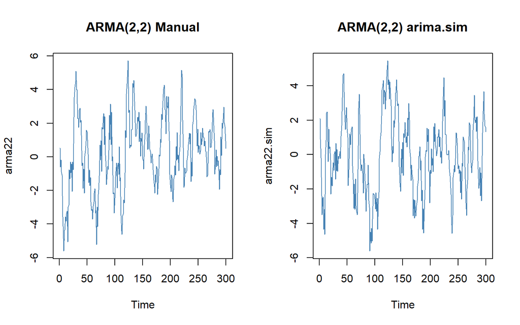

```r
par(mfrow = c(1, 2))
ts.plot(arma22, main = "ARMA(2,2) Manual", col = "steelblue")
ts.plot(arma22.sim, main = "ARMA(2,2) arima.sim", col = "steelblue")
```

```r
par(mfrow = c(1, 1))
```

Kedua plot bergerak di sekitar rataan konstan tanpa tren, sehingga data **stasioner dalam rataan**, konsisten dengan hasil pengecekan syarat kestasioneran di atas.

### Plot ACF

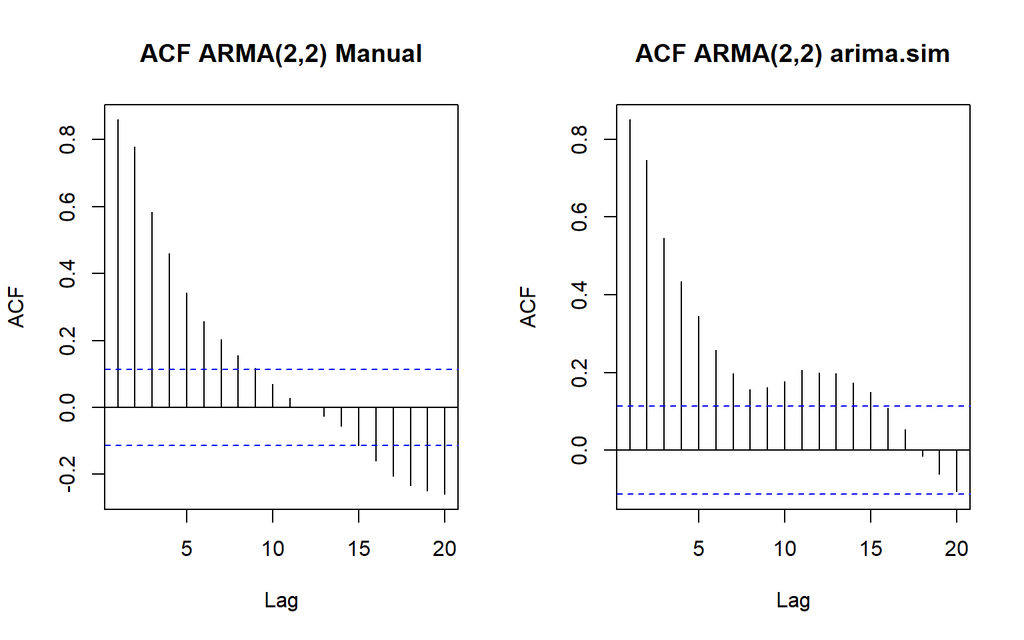

```r
par(mfrow = c(1, 2))
acf(arma22, lag.max = 20, main = "ACF ARMA(2,2) Manual")
acf(arma22.sim, lag.max = 20, main = "ACF ARMA(2,2) arima.sim")
```

```r
par(mfrow = c(1, 1))
```

Plot ACF *tails off* (meluruh bertahap), tidak terputus tegas pada lag tertentu, yang merupakan ciri komponen AR pada model campuran ARMA.

### Plot PACF

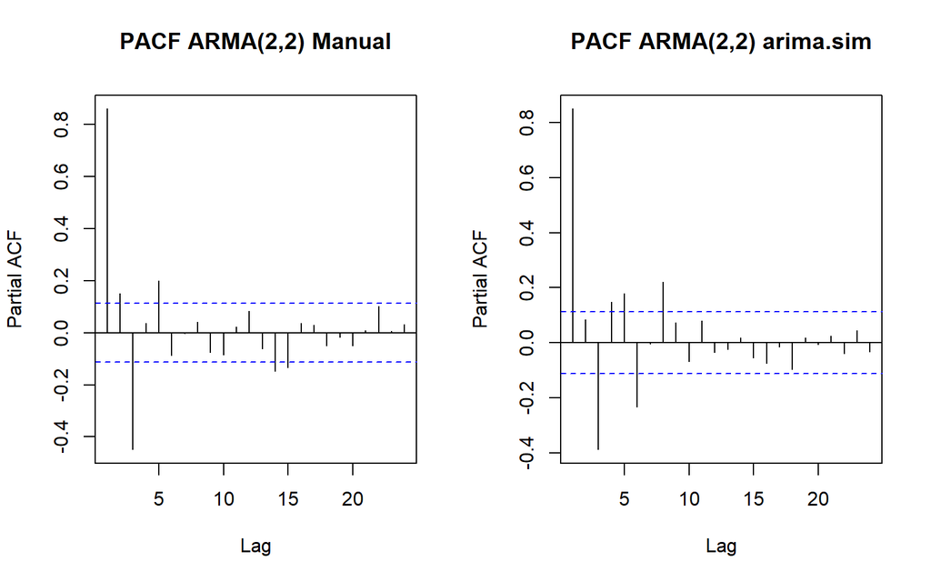

```r
par(mfrow = c(1, 2))
pacf(arma22, main = "PACF ARMA(2,2) Manual")
pacf(arma22.sim, main = "PACF ARMA(2,2) arima.sim")
```

```r
par(mfrow = c(1, 1))
```

Plot PACF juga *tails off*. ACF dan PACF yang sama-sama *tails off* merupakan ciri khas proses **ARMA campuran** (bukan AR maupun MA murni).

### Plot EACF

```r
TSA::eacf(arma22)
```

```
## AR/MA
##   0 1 2 3 4 5 6 7 8 9 10 11 12 13
## 0 x x x x x x x x x o o  o  o  o
## 1 x x o o o o o o o o o  o  o  o
## 2 x x x o o o o o o o o  o  o  o
## 3 o x x o o o o o o o o  o  o  o
## 4 x x o x x o o o o o o  o  o  o
## 5 x x x x o o o o o o o  o  o  o
## 6 o x o x o o o o o o o  o  o  o
## 7 x o o x x o x o o o o  o  o  o
```

```r
TSA::eacf(arma22.sim)
```

```
## AR/MA
##   0 1 2 3 4 5 6 7 8 9 10 11 12 13
## 0 x x x x x x x x x x x  x  x  x
## 1 o x x o o o o x o o o  o  o  o
## 2 x x x o o o o x o o o  o  o  o
## 3 x x o o o o o o o o x  o  o  o
## 4 x x x o o x o o o o x  o  o  o
## 5 x x x o o x o o o o x  o  o  o
## 6 o x o o o x o o o o o  o  o  o
## 7 o x x x x x x o o o o  o  o  o
```

## 3.3 Scatterplot Antar Lag

Analisis berikut memakai data hasil pembangkitan manual (`arma22`).

#### Korelasi antara $Y_t$ dengan $Y_{t-1}$

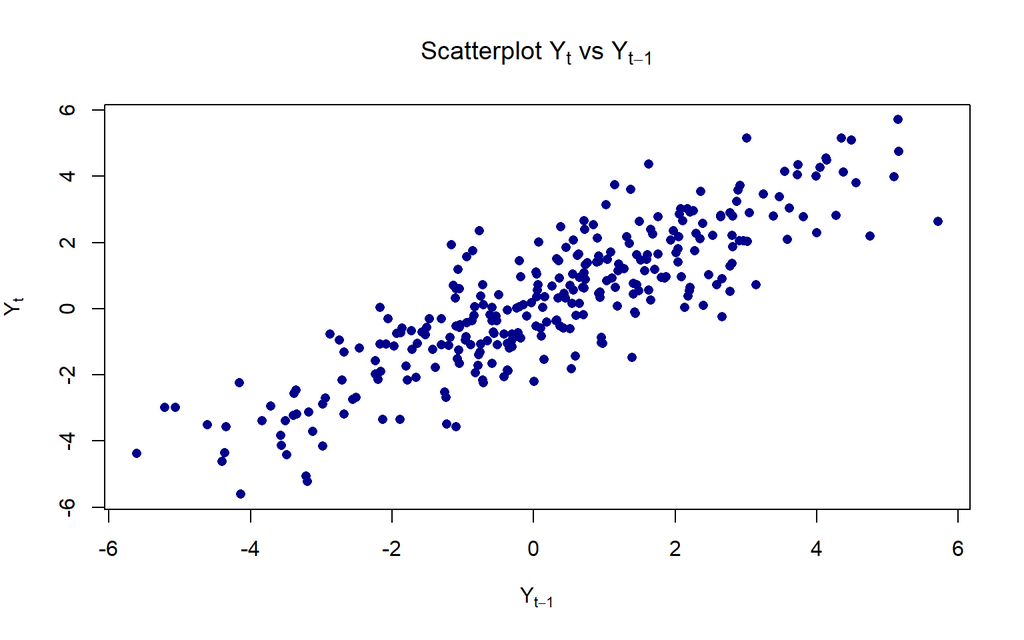

```r
# Yt
yt_arma22 <- arma22[-1]
# Yt-1
yt1_arma22 <- arma22[-n]

plot(y = yt_arma22, x = yt1_arma22, pch = 16, col = "darkblue",
     main = expression(paste("Scatterplot ", Y[t], " vs ", Y[t-1])),
     xlab = expression(Y[t-1]), ylab = expression(Y[t]))
```

```r
cor(yt_arma22, yt1_arma22)
```

```
## [1] 0.8598115
```

Tampak hubungan positif yang sangat kuat antara $Y_t$ dan $Y_{t-1}$, mencerminkan pengaruh gabungan komponen AR dan MA.

#### Korelasi antara $Y_t$ dengan $Y_{t-2}$

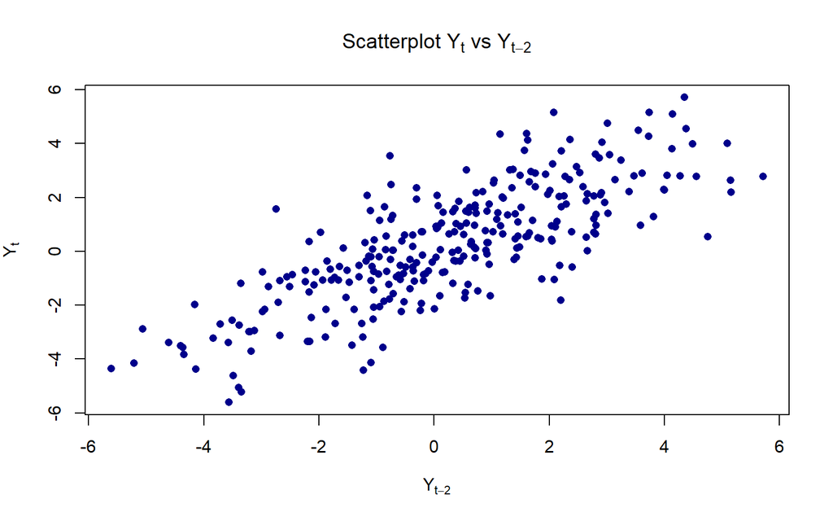

```r
# Yt
yt_arma22_2 <- arma22[-c(1, 2)]
# Yt-2
yt2_arma22 <- arma22[-c(n - 1, n)]

plot(y = yt_arma22_2, x = yt2_arma22, pch = 16, col = "darkblue",
     main = expression(paste("Scatterplot ", Y[t], " vs ", Y[t-2])),
     xlab = expression(Y[t-2]), ylab = expression(Y[t]))
```

```r
cor(yt_arma22_2, yt2_arma22)
```

```
## [1] 0.7786713
```

Hubungan positif yang kuat masih tampak pada lag 2, sejalan dengan pola ACF yang *tails off* perlahan.

#### Korelasi antara $Y_t$ dengan $Y_{t-3}$

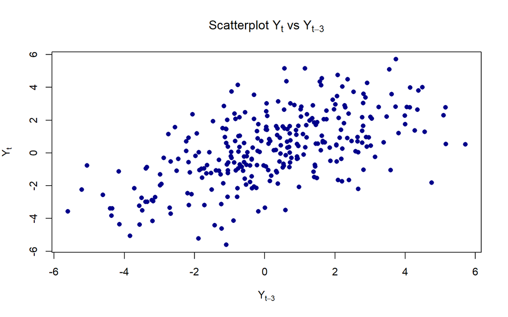

```r
# Yt
yt_arma22_3 <- arma22[-c(1, 2, 3)]
# Yt-3
yt3_arma22 <- arma22[-c(n - 2, n - 1, n)]

plot(y = yt_arma22_3, x = yt3_arma22, pch = 16, col = "darkblue",
     main = expression(paste("Scatterplot ", Y[t], " vs ", Y[t-3])),
     xlab = expression(Y[t-3]), ylab = expression(Y[t]))
```

```r
cor(yt_arma22_3, yt3_arma22)
```

```
## [1] 0.5842782
```

Hubungan positif masih tampak walau melemah, konsisten dengan sifat ARMA(2,2) yang autokorelasinya meluruh bertahap dan tidak terputus tegas pada lag tertentu (berbeda dengan MA(2) yang langsung nol setelah lag 2).

## 3.4 Autokorelasi: Data Bangkitan vs Teoritis

Untuk model ARMA campuran, perhitungan manual autokorelasi teoritis relatif rumit karena melibatkan komponen AR dan MA sekaligus. Secara teori, untuk $k>q=2$ autokorelasi ARMA(2,2) mengikuti rekursi AR biasa ($\rho_k=\phi_1\rho_{k-1}+\phi_2\rho_{k-2}$), sedangkan $\rho_1$ dan $\rho_2$ juga dipengaruhi $\theta_1$ dan $\theta_2$. Nilai eksaknya lebih praktis dihitung dengan fungsi `ARMAacf()` di R:

```r
ARMAacf(ar = c(phi1, phi2), ma = c(theta1, theta2), lag.max = 3, pacf = FALSE)
```

```
##         0         1         2         3
## 1.0000000 0.8591993 0.7491908 0.5464353
```

Diperoleh $\rho_1=0.8592$, $\rho_2=0.7492$, dan $\rho_3=0.5464$.

**Perbandingan hasil:**

| Lag | Autokorelasi Data Bangkitan | Autokorelasi Teoritis |
| --- | --- | --- |
| 1 | 0.8598 | 0.8592 |
| 2 | 0.7787 | 0.7492 |
| 3 | 0.5843 | 0.5464 |

Autokorelasi dari data bangkitan **mendekati** nilai teoritisnya, sehingga data hasil pembangkitan sudah cukup mewakili model ARMA(2,2) yang diinginkan.

# 4. Ringkasan

[output not shown]